# Video Game Sales With Ratings Data

Cam Simmons

Oct 11, 2017

## Context

“Motivated by Gregory Smith’s web scrape of VGChartz Video Games Sales, [this](https://www.kaggle.com/rush4ratio/video-game-sales-with-ratings) data set simply extends the number of variables with another web scrape from Metacritic. Unfortunately, there are missing observations as Metacritic only covers a subset of the platforms. Also, a game may not have all the observations of the additional variables discussed below. Complete cases are ~ 6,900” (Kaggle)

## Acknowledgements

“This repository, https://github.com/wtamu-cisresearch/scraper, after a few adjustments worked extremely well!” (Kaggle)

## Variables

The outcome in this dataset is NA_Sales. There were 10 predictors (after removing zero variance predictors), including critic scores and user scores. Some of the predictors were categorical and some continuous.

## Missing Values

For simplicity and because n was large enough (more on this in diagnostic section below), I removed all NA values from the data set. One alternative could be to use k-nearest neighbours imputation or MICE from the mice R package which “.. imputes an incomplete column (the target column) by generating ‘plausible’ synthetic values given other columns in the data” -docs.

## Matrix Plot

The following is for examining correlations and the distributions of the predictors and outcome.

Note: Critic_count and User_Count are discrete variables. Their usefulness in the matrix plot may be limited.

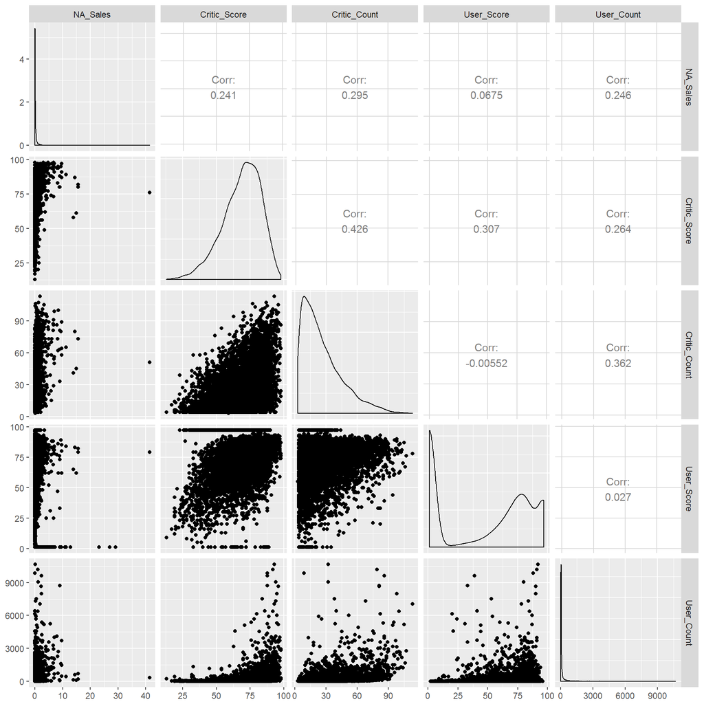

As shown in the plot above, NA_Sales is highly right skewed. Most of the variables are skewed in one way or another.

For a .75 cutoff for correlation between predictors, none were removed.

Based on first observations, this may be a difficult dataset to model because of the severe imbalances.

## Plotting predictors vs outcome

It may be important to see how the predictors are related to the outcome in further stages such as picking a model to fit the data.

In plots 1 and 2 below, the Rating is along the top. For example, in “AO” standing for Adults Only, there appears to be only one sample.

[figure not shown]

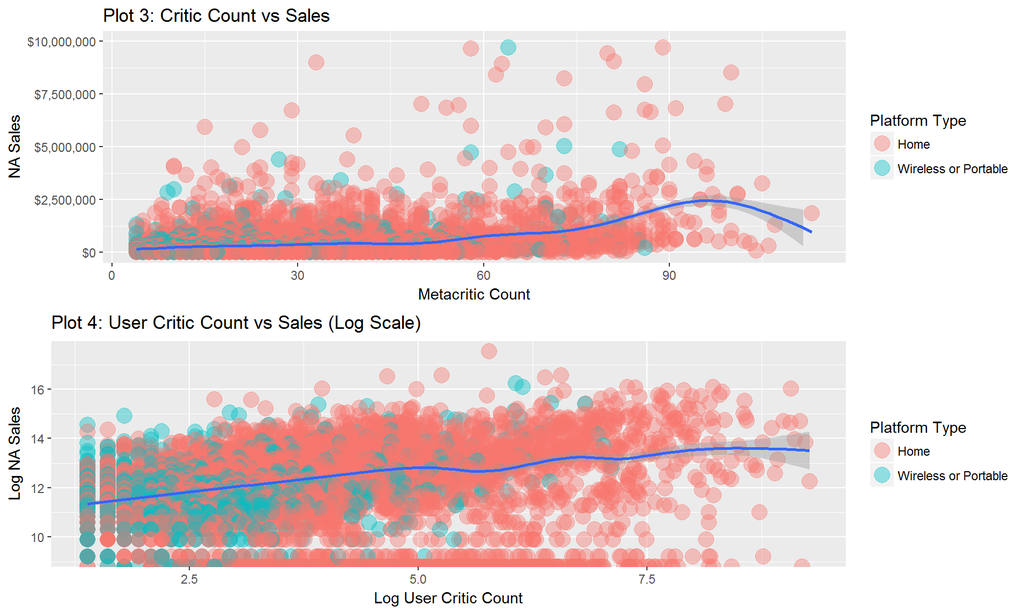

Plot 1 suggests some nonlinear relationships between Critic Score and Sales (Rating: E and M in particular). There appears to be a curvilinear relationship between the number of critic reviews and NA Sales (plot 3). However, intuitively this may not make a lot of sense so more investigation could be helpful in determining the true relationship.

## Exploring further: how have video game sales been doing since 1980?

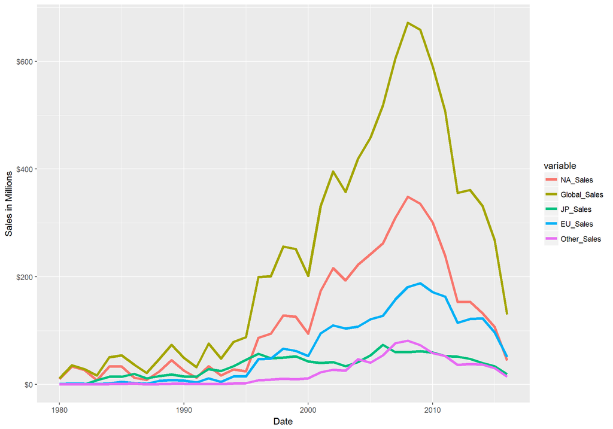

## Which publishers have the most sales by area?

Inspired by a kaggle user, who pointed me to the viridis package.

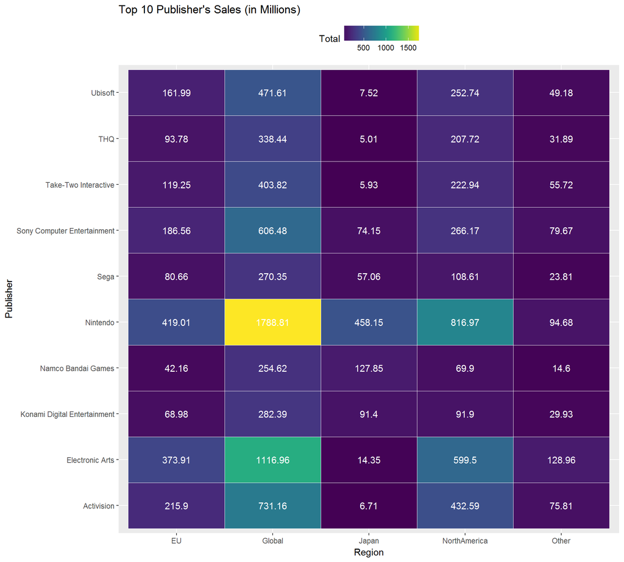

## Modeling North American Sales

Four models total were chosen to model NA sales. For resampling, all of the models used 10 fold cross-validation and a test/train set (train on 2014 and prior, and test on after 2014). First, I chose a linear regression model because its interpretable. And for this data, has performed well in comparison to the other models. I chose a single tree for interpretability as well, but I also wanted to see what features it would select and deem most important. I used a boosted regression tree, gbm. gbm’s final prediction is an ensemble of models, and trees are used as a base learner (Applied Predictive Modeling, 2013). It uses a bagging technique that randomly selects a fraction of the training data (APM, 2013). Finally, I used a random forest for the last model because I wanted to see how the interpretability vs accuracy tradeoff played out in this problem. A bwplot is below for root mean squared error and r squared.

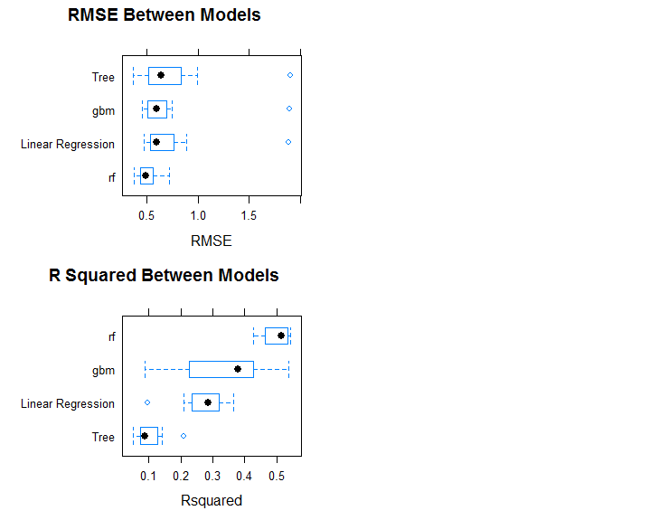

The random forest model had the lowest RMSE at 0.5121583 and the highest RSquared of 0.4978058. One important thing to note is these are resampling results, not test set results. So, these results are optimistic. It’s also important to remember a high R squared isn’t necessarily everything, and is a measure of correlation, not accuracy (Applied Predictive Modeling, 2013).

## Test Set Results

The 4 models then were applied to the test set. The results are below.

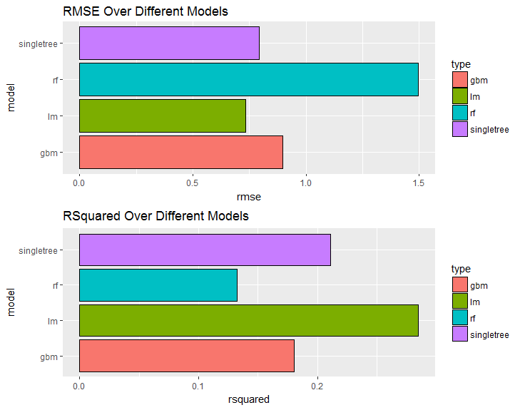

As seen above, the model that performed the best was the linear model. This was suprising as out of the 4 models chosen, is highly intepretable (same with the single tree). Although this was less so after the ~400 dummy variables were added to the equation. The random forest’s performance drastically dropped when the model was applied to the test set. It did the best in resampling but the worst on the test set. This suggests possible overfitting.

## Diagnostic Plots For Select Models

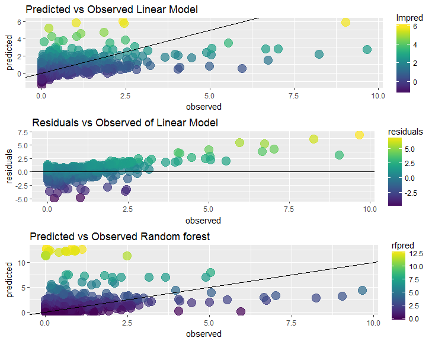

As seen in the random forest graph above, the model over predicts when the observed is between 0 and 2.5 million sales. Also seen above in the linear model, it over predicts when the sales are between 0 and 2.5 and under predicts when sales are more than approximately 3 million.

## Conclusion

From the diagnostic plots and from the performance metrics (RMSE, RSquared), it seems none of the models fit the data particularly well. The RMSE for the lm model was .7328557 and 1.49756 for the random forest, in millions of sales.

To improve results, before discarding the NA values I would try models that are able to handle missing values to see if this improves performance. According to Applied Predictive Modeling (2013), in a lot of cases to improve performance, the practitioner should preprocess the data (ie. box-cox transformation).

## Final Notes

For most of the previous data I have worked with, predictive modeling has shown an “edge” over baseline models (classification), high accuracy rates (depending on the model and tuning parameters), and low RMSEs (regression) for the task at hand.

Whats up next? For my next example I have chosen a dataset from the UCI machine learning database, a classification problem. I expect the results to be much more favorable.

## References

Kuhn, M., & Johnson, K. (2013). Applied Predictive Modeling.

Kaggle.com